# Punto de cambio

El conjunto de datos `coal` del paquete `boot` proporciona las fechas (entre el 15 de marzo de 1851 y el 22 de marzo de 1962) de 191 explosiones en minas de carbón que provocaron diez o más víctimas. Las siguientes expresiones de *R* extraen los años de las explosiones y calculan una tabla de frecuencias absolutas.

```r
data(coal, package = "boot")
y <- coal$date |>
  floor() |>
  factor(levels = 1851:1962) |>
  table()
y
```

```
##
## 1851 1852 1853 1854 1855 1856 1857 1858 1859 1860 1861 1862 1863 1864 1865 1866
##    4    5    4    1    0    4    3    4    0    6    3    3    4    0    2    6
## 1867 1868 1869 1870 1871 1872 1873 1874 1875 1876 1877 1878 1879 1880 1881 1882
##    3    3    5    4    5    3    1    4    4    1    5    5    3    4    2    5
## 1883 1884 1885 1886 1887 1888 1889 1890 1891 1892 1893 1894 1895 1896 1897 1898
##    2    2    3    4    2    1    3    2    2    1    1    1    1    3    0    0
## 1899 1900 1901 1902 1903 1904 1905 1906 1907 1908 1909 1910 1911 1912 1913 1914
##    1    0    1    1    0    0    3    1    0    3    2    2    0    1    1    1
## 1915 1916 1917 1918 1919 1920 1921 1922 1923 1924 1925 1926 1927 1928 1929 1930
##    0    1    0    1    0    0    0    2    1    0    0    0    1    1    0    2
## 1931 1932 1933 1934 1935 1936 1937 1938 1939 1940 1941 1942 1943 1944 1945 1946
##    3    3    1    1    2    1    1    1    1    2    3    3    0    0    0    1
## 1947 1948 1949 1950 1951 1952 1953 1954 1955 1956 1957 1958 1959 1960 1961 1962
##    4    0    0    0    1    0    0    0    0    0    1    0    0    1    0    1
```

Un análisis de los datos muestra que con el cambio de siglo pudo haber ocurrido una variación en el promedio del número de desastres anuales. Es natural modelizar entonces los datos mediante un *modelo de punto de cambio*. En este modelo se asumen dos regímenes para $n$ variables aleatorias:
$$\begin{align*}
Y_{i}
&\sim \mathrm{Poi}(\lambda_{1}), \quad \text{para \( i = 1,
\dotsc, M \)} \\
Y_{i}
&\sim \mathrm{Poi}(\lambda_{2}), \quad \text{para \( i = M + 1,
\dotsc, n \)}
\end{align*}$$
donde $\lambda_{1}, \lambda_{2} ∈ \mathbb{R}_{>0}$ y $M ∈ \{1, \dotsc, n - 1\}$ (es decir, $1850 + M$ sería el último año con un promedio de $\lambda_1$ explosiones y $1850 + M + 1$ sería el primer año con un promedio de $\lambda_2$ explosiones).

Una distribución a priori adecuada para cada parámetro $\lambda_{j}$ es $\mathrm{Gamma}(\alpha_{j}, \beta_{j})$, mientras que para el parámetro $M$ es $\mathrm{U}(\{1, \dotsc, n - 1\})$. La densidad a posteriori de los tres parámetros es entonces
$$\begin{equation*}
f_{pos}(\lambda_{1}, \lambda_{2}, M \mid y_{1}, \dotsc, y_{n}) \propto
\Biggl(\prod_{i = 1}^{M} \lambda_{1}^{y_{i}}
\mathrm{e}^{-\lambda_{1}}\Biggr)
\Biggl(\prod_{i = M + 1}^{n} \lambda_{2}^{y_{i}}
\mathrm{e}^{-\lambda_{2}}\Biggr)
\lambda_{1}^{\alpha_{1} - 1} \mathrm{e}^{-\beta_{1} \lambda_{1}}
\lambda_{2}^{\alpha_{2} - 1} \mathrm{e}^{-\beta_{2} \lambda_{2}}
\end{equation*}$$

Por tanto, las densidades condicionales completas para cada parámetro $\lambda_{1}, \lambda_{2}$ y $M$ son
$$\begin{align*}
f(\lambda_{1} \mid y_{1}, \dotsc, y_{n}, \lambda_{2}, M)
&\propto \lambda_{1}^{\alpha_{1} - 1 + \sum_{i = 1}^{M} y_{i}}
\mathrm{e}^{-(\beta_{1} + M) \lambda_{1}} \\
f(\lambda_{2} \mid y_{1}, \dotsc, y_{n}, \lambda_{1}, M)
&\propto \lambda_{2}^{\alpha_{2} - 1 + \sum_{i = M + 1}^{n} y_{i}}
\mathrm{e}^{-(\beta_{2} + n - M) \lambda_{2}} \\
\mathbb{P}(M \mid y_{1}, \dotsc, y_{n}, \lambda_{1}, \lambda_{2})
&\propto
\lambda_{1}^{\sum_{i = 1}^{M} y_{i}}
\lambda_{2}^{\sum_{i = M + 1}^{n} y_{i}}
\mathrm{e}^{(\lambda_{2} - \lambda_{1}) M}
\end{align*}$$

En consecuencia, es fácil generar muestras de esas variables condicionadas, ya que
$$\begin{align*}
\lambda_{1} \mid y_{1}, \dotsc, y_{n}, \lambda_{2}, M
&\sim \mathrm{Gamma}\Bigl(\alpha_{1} + \sum_{i = 1}^{M} y_{i},
\beta_{1} + M\Bigr) \\
\lambda_{2} \mid y_{1}, \dotsc, y_{n}, \lambda_{1}, M
&\sim \mathrm{Gamma}\Bigl(\alpha_{2} + \sum_{i = M + 1}^{n} y_{i},
\beta_{2} + n - M\Bigr) \\
M \mid y_{1}, \dotsc, y_{n}, \lambda_{1}, \lambda_{2}
&\sim \mathrm{Cat}\Bigl(
c \lambda_{1}^{y_{1}} \lambda_{2}^{\sum_{i = 2}^{n} y_{i}}
\mathrm{e}^{(\lambda_{2} - \lambda_{1}) 1},
\dotsc,
c \lambda_{1}^{\sum_{i = 1}^{n - 1} y_{i}} \lambda_{2}^{y_{n}}
\mathrm{e}^{(\lambda_{2} - \lambda_{1}) (n - 1)}
\Bigr)
\end{align*}$$
donde $c$ es la constante normalizadora que hace que la suma de las probabilidades para cada posible valor de $M$ sea $1$.

Estamos entonces en condiciones de estimar los valores esperados de los parámetros $\lambda_{1}, \lambda_{2}$ y $M$ mediante un muestreador de Gibbs. Para ello tomaremos $\alpha_{1} = \alpha_{2} = 0.5$ y $\beta_{1} = \beta_{2} = 1$ como valores de los hiperparámetros.

```r
alfa1 <- 0.5
alfa2 <- 0.5
beta1 <- 1
beta2 <- 1
```

Analizando las distribuciones condicionales completas se observa que la implementación del muestreador de Gibbs se verá facilitada si se precalculan las frecuencias absolutas acumuladas de las explosiones.

```r
n <- length(y)
y_total <- sum(y)
y_acumulada_hasta <- cumsum(y[-n])
y_acumulada_desde <- y_total - y_acumulada_hasta
```

Aplicamos el método de las medias por lotes para calcular intervalos de confianza de las estimaciones (comprobamos con un gráfico de autocorrelación que las medias de cada lote están prácticamente incorreladas). Como estado inicial consideramos que, tal y como sugieren los datos, el cambio de régimen se produce con el cambio de siglo.

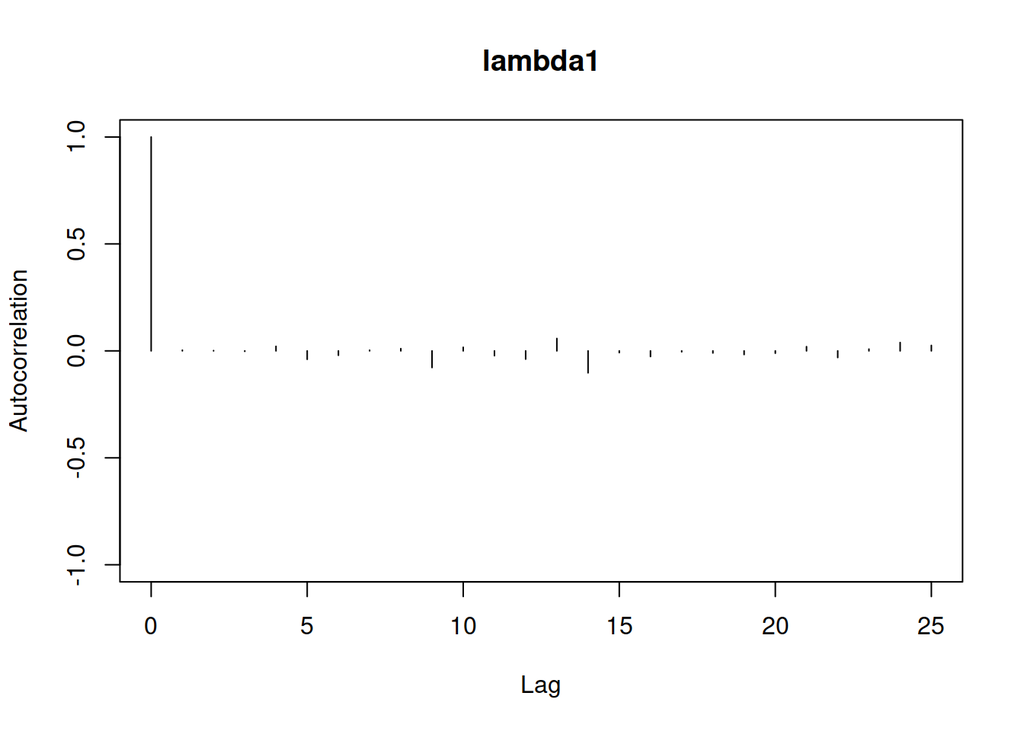

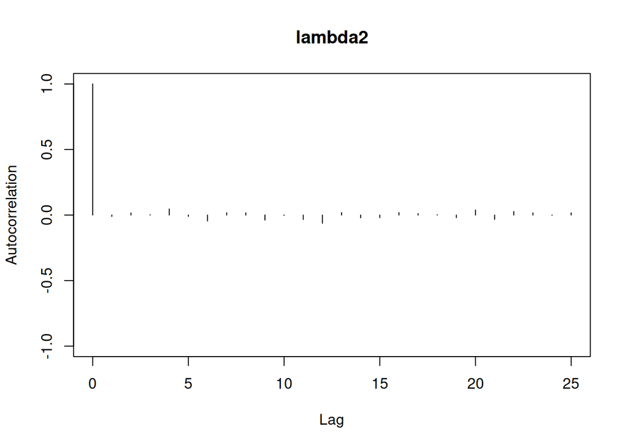

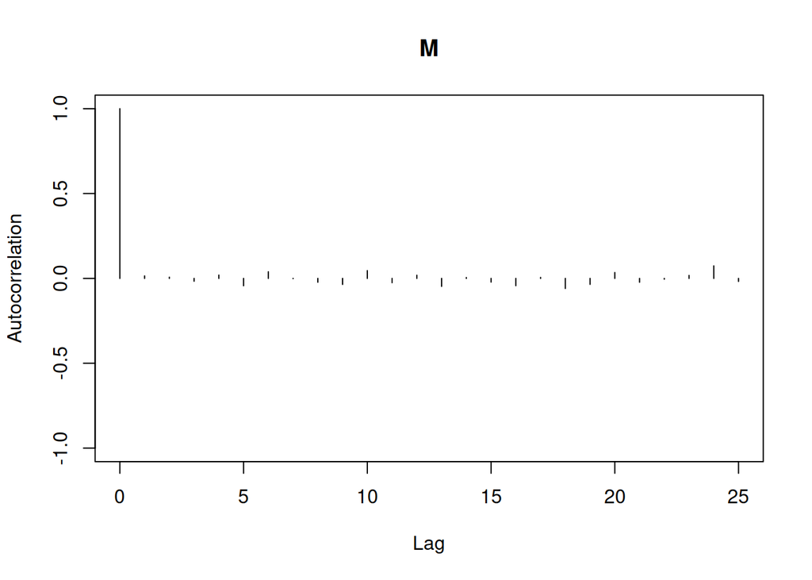

```r
numero_lotes <- 1e3
longitud_lote <- 1e2
medias_lotes <-
  matrix(
    nrow = numero_lotes, ncol = 3,
    dimnames = list(NULL, c("lambda1", "lambda2", "M"))
  )
lambda1 <- y[as.character(1851:1900)] |> mean()
lambda2 <- y[as.character(1901:1962)] |> mean()
M <- 50
for (i in seq_len(numero_lotes)) {
  suma_lambda1 <- 0
  suma_lambda2 <- 0
  suma_M <- 0
  for (t in seq_len(longitud_lote)) {
    suma_lambda1 <- suma_lambda1 + lambda1
    suma_lambda2 <- suma_lambda2 + lambda2
    suma_M <- suma_M + M
    lambda1 <- rgamma(1,
      shape = alfa1 + y_acumulada_hasta[[M]],
      rate = beta1 + M
    )
    lambda2 <- rgamma(1,
      shape = alfa2 + y_acumulada_desde[[M]],
      rate = beta2 + n - M
    )
    probs_M <- lambda1^y_acumulada_hasta *
      lambda2^y_acumulada_desde *
      exp((lambda2 - lambda1) * seq_len(n - 1))
    M <- sample(seq_len(n - 1), size = 1, prob = probs_M)
  }
  medias_lotes[i, ] <-
    c(suma_lambda1, suma_lambda2, suma_M) / longitud_lote
}

library(coda)

medias_lotes |>
  mcmc() |>
  autocorr.plot(auto.layout = FALSE)
```

```r
library(purrr)

estimaciones <- medias_lotes |>
  array_branch(margin = 2) |>
  map_dbl(mean)
estimaciones
```

```
##    lambda1    lambda2          M
##  3.0509204  0.9146111 40.1349400
```

```r
errores_estandar <- medias_lotes |>
  array_branch(margin = 2) |>
  map_dbl(var) |>
  magrittr::divide_by(numero_lotes) |>
  sqrt()

probabilidad_cobertura <- 0.95
alfa <- 1 - probabilidad_cobertura
percentil <- qnorm(1 - alfa / 2)
map2(
  estimaciones,
  errores_estandar,
  \(estimacion, error) estimacion + c(-1, 1) * error * percentil
)
```

```
## $lambda1
## [1] 3.048996 3.052845
##
## $lambda2
## [1] 0.9138492 0.9153730
##
## $M
## [1] 40.11829 40.15159
```